# Complex Networks 4

Walter Quattrociocchi

- **Network Descriptives**
- **Distances**
- **Subgroups and communities**

### Network Descriptives

- Density: The proportion of present edges from all possible ties.

```r
library(igraph)
nodes <- read.csv("Dataset1-Media-Example-NODES.csv", header=T, as.is=T)
links <- read.csv("Dataset1-Media-Example-EDGES.csv", header=T, as.is=T)
net <- graph_from_data_frame(d=links, vertices=nodes, directed=T)
edge_density(net, loops=F)
```

```
[1] 0.1911765
```

```r
ecount(net)/(vcount(net)*(vcount(net)-1)) #for a directed network
```

```
[1] 0.1911765
```

### Network Descriptives

- Reciprocity: The proportion of reciprocated ties (for a directed network).

```r
reciprocity(net)
```

```
[1] 0.3921569
```

```r
dyad_census(net) # Mutual, asymmetric, and null node pairs
```

```
$mut
[1] 10

$asym
[1] 31

$null
[1] 95
```

```r
2*dyad_census(net)$mut/ecount(net) # Calculating reciprocity
```

```
[1] 0.3846154
```

### Network Descriptives

Transitivity (or Clustering Coefficient)

- global: ratio of triangles (direction disregarded) to connected triples
- local: ratio of triangles to connected triples each vertex is part of

```r
transitivity(net, type="global")  # net is treated as an undirected network
```

```
[1] 0.372549
```

```r
transitivity(as.undirected(net, mode="collapse")) # same as above
```

```
[1] 0.372549
```

```r
transitivity(net, type="local")
```

```
 [1] 0.13333333 0.28571429 0.11538462 0.19444444 0.50000000 0.14285714
 [7] 0.20000000 0.06666667 0.20000000 0.30000000 0.33333333 0.20000000
[13] 0.16666667 0.16666667 0.20000000 0.33333333 0.20000000
```

### Network Descriptives

Triad types (per Davis & Leinhardt):

```r
# 003  A, B, C, empty triad.
# 012  A->B, C
# 102  A<->B, C
# 021D A<-B->C
# 021U A->B<-C
# 021C A->B->C
# 111D A<->B<-C
# 111U A<->B->C
# 030T A->B<-C, A->C
# 030C A<-B<-C, A->C.
# 201  A<->B<->C.
# 120D A<-B->C, A<->C.
# 120U A->B<-C, A<->C.
# 120C A->B->C, A<->C.
# 210  A->B<->C, A<->C.
# 300  A<->B<->C, A<->C, completely connected.

triad_census(net) # for directed networks
```

```
 [1] 244 231  90  13  11  27  15  22   4   1   8   4   4   3   3   0
```

### Network Descriptives

Diameter (longest geodesic distance)

```r
#Note that edge weights are used by default, unless set to NA.
diameter(net, directed=F, weights=NA)
```

```
[1] 4
```

```r
diameter(net, directed=F)
```

```
[1] 28
```

```r
diam <- get_diameter(net, directed=T)
diam
```

```
+ 7/17 vertices, named, from b8afdea:
[1] s12 s06 s17 s04 s03 s08 s07
```

### Network Descriptives

Diameter (longest geodesic distance)

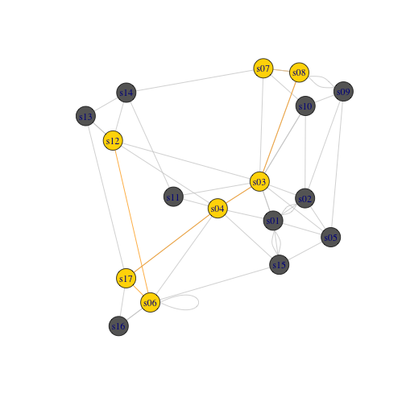

```r
# Color nodes along the diameter:
vcol <- rep("gray40", vcount(net))
vcol[diam] <- "gold"
ecol <- rep("gray80", ecount(net))
ecol[E(net, path=diam)] <- "orange"
# E(net, path=diam) finds edges along a path, here 'diam'
plot(net, vertex.color=vcol, edge.color=ecol, edge.arrow.mode=0)
```

### Network Descriptives

- Node degrees: 'degree' -has a mode of 'in' for in-degree,
  - 'out' for out-degree,
  - and 'all' or 'total' for total degree.

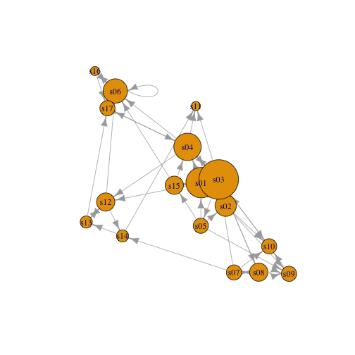

```r
deg <- degree(net, mode="all")
plot(net, vertex.size=deg*3)
```

### Network Descriptives

- Node degrees: 'degree'

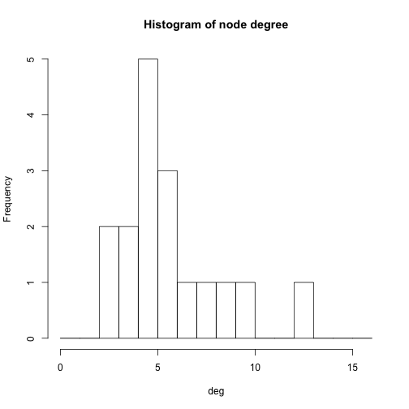

```r
hist(deg, breaks=1:vcount(net)-1, main="Histogram of node degree")
```

### Network Descriptives

- Degree Distribution

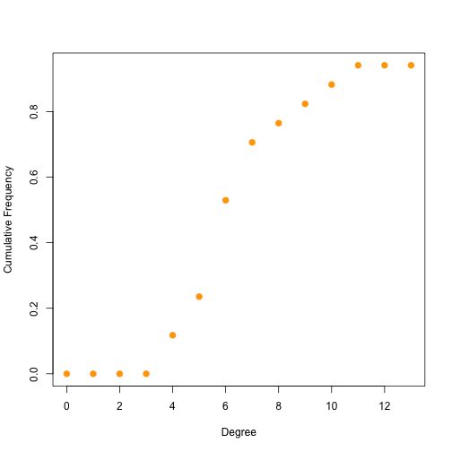

```r
deg.dist <- degree_distribution(net, cumulative=T, mode="all")
plot( x=0:max(deg), y=1-deg.dist, pch=19, cex=1.2, col="orange",
      xlab="Degree", ylab="Cumulative Frequency")
```

### Centrality

- Centrality & centralization

Centrality functions (vertex level) and centralization functions (graph level). The centralization functions return “res” - vertex centrality, “centralization”, and “theoretical_max” - maximum centralization score for a graph of that size. The centrality functions can run on a subset of nodes (set with the “vids” parameter)

```r
# Degree (number of ties)
degree(net, mode="in")
```

```
s01 s02 s03 s04 s05 s06 s07 s08 s09 s10 s11 s12 s13 s14 s15 s16 s17
  5   3   6   4   1   5   1   2   4   4   3   3   2   2   2   1   4
```

```r
centr_degree(net, mode="in", normalized=T)
```

```
$res
 [1] 5 3 6 4 1 5 1 2 4 4 3 3 2 2 2 1 4

$centralization
[1] 0.1838235

$theoretical_max
[1] 272
```

### Centrality

Closeness (centrality based on distance to others in the graph) Inverse of the node's average geodesic distance to others in the network

```r
closeness(net, mode="all", weights=NA)
```

```
       s01        s02        s03        s04        s05        s06
0.03333333 0.03030303 0.04166667 0.03846154 0.03225806 0.03125000
       s07        s08        s09        s10        s11        s12
0.03030303 0.02857143 0.02564103 0.02941176 0.03225806 0.03571429
       s13        s14        s15        s16        s17
0.02702703 0.02941176 0.03030303 0.02222222 0.02857143
```

```r
centr_clo(net, mode="all", normalized=T)
```

```
$res
 [1] 0.5333333 0.4848485 0.6666667 0.6153846 0.5161290 0.5000000 0.4848485
 [8] 0.4571429 0.4102564 0.4705882 0.5161290 0.5714286 0.4324324 0.4705882
[15] 0.4848485 0.3555556 0.4571429

$centralization
[1] 0.3753596

$theoretical_max
[1] 7.741935
```

### Centrality

Eigenvector (centrality proportional to the sum of connection centralities)

- Values of the first eigenvector of the graph adjacency matrix

```r
eigen_centrality(net, directed=T, weights=NA)
```

[output not shown]

[output cut: 16 more lines]

```

$options$iter
[1] 7

$options$nconv
[1] 1

$options$numop
[1] 31

$options$numopb
[1] 0

$options$numreo
[1] 18
```

```r
centr_eigen(net, directed=T, normalized=T)
```

[output not shown]

[output cut: 20 more lines]

```
$options$numop
[1] 31

$options$numopb
[1] 0

$options$numreo
[1] 18


$centralization
[1] 0.4946416

$theoretical_max
[1] 16
```

### Centrality

Betweenness (centrality based on a broker position connecting others)

- Number of geodesics that pass through the node or the edge

```r
betweenness(net, directed=T, weights=NA)
```

```
       s01        s02        s03        s04        s05        s06
 26.857143   6.238095 126.511905  92.642857  13.000000  20.333333
       s07        s08        s09        s10        s11        s12
  1.750000  21.000000   1.000000  15.000000   0.000000  33.500000
       s13        s14        s15        s16        s17
 20.000000   4.000000   5.666667   0.000000  58.500000
```

```r
edge_betweenness(net, directed=T, weights=NA)
```

```
 [1]  6.619048  6.619048 11.785714  8.333333  6.500000 11.166667 21.333333
 [8]  4.250000  4.250000 16.000000 64.476190  9.500000  3.261905  3.261905
[15] 15.000000  1.000000 15.000000 17.000000 16.750000  2.000000  1.250000
[22]  8.000000 12.500000  4.000000 26.000000 18.000000 14.500000 17.000000
[29]  7.500000  4.500000  2.738095 23.000000 11.000000 31.000000  9.011905
[36] 18.000000 28.500000  0.000000  3.000000  6.500000 17.000000  8.666667
[43] 74.500000 11.750000 34.000000  4.500000  6.333333  8.809524  5.333333
[50]  3.000000 28.000000 10.000000
```

```r
centr_betw(net, directed=T, normalized=T)
```

```
$res
 [1]  26.857143   6.238095 126.511905  92.642857  13.000000  20.333333
 [7]   1.750000  21.000000   1.000000  15.000000   0.000000  33.500000
[13]  20.000000   4.000000   5.666667   0.000000  58.500000

$centralization
[1] 0.4439329

$theoretical_max
[1] 3840
```

### Hubs and authorities

The hubs and authorities algorithm developed by Jon Kleinberg was initially used to examine web pages. Hubs were expected to contain catalogues with a large number of outgoing links; while authorities would get many incoming links from hubs, presumably because of their high-quality relevant information.

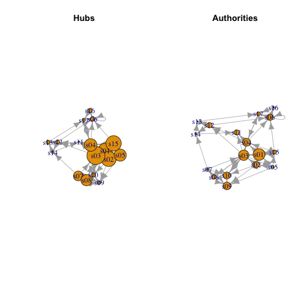

```r
hs <- hub_score(net, weights=NA)$vector
as <- authority_score(net, weights=NA)$vector

par(mfrow=c(1,2))
 plot(net, vertex.size=hs*50, main="Hubs")
 plot(net, vertex.size=as*30, main="Authorities")
```

### Distances and paths

- Average path length The mean of the shortest distance between each pair of nodes in the network (in both directions for directed graphs).

```r
mean_distance(net, directed=F)
```

```
[1] 2.058824
```

```r
mean_distance(net, directed=T)
```

```
[1] 2.742188
```

### Distances and paths

We can also find the length of all shortest paths in the graph:

```r
distances(net) # with edge weights
```

```
    s01 s02 s03 s04 s05 s06 s07 s08 s09 s10 s11 s12 s13 s14 s15 s16 s17
s01   0   4   2   6   1   5   3   4   3   4   3   3   9   4   7  26   8
s02   4   0   4   8   3   7   5   6   1   5   5   5  11   6   9  28  10
s03   2   4   0   4   1   3   1   2   3   2   1   1   7   2   5  24   6
s04   6   8   4   0   5   1   5   6   7   6   5   3   3   6   1  22   2
s05   1   3   1   5   0   4   2   3   2   3   2   2   8   3   6  25   7
s06   5   7   3   1   4   0   4   5   6   5   4   2   4   5   2  21   3
s07   3   5   1   5   2   4   0   3   4   3   2   2   8   3   6  25   7
s08   4   6   2   6   3   5   3   0   5   4   3   3   9   4   7  26   8
s09   3   1   3   7   2   6   4   5   0   5   4   4  10   5   8  27   9
s10   4   5   2   6   3   5   3   4   5   0   3   3   9   4   7  26   8
s11   3   5   1   5   2   4   2   3   4   3   0   2   8   1   6  25   7
s12   3   5   1   3   2   2   2   3   4   3   2   0   6   3   4  23   5
s13   9  11   7   3   8   4   8   9  10   9   8   6   0   9   4  22   1
s14   4   6   2   6   3   5   3   4   5   4   1   3   9   0   7  26   8
s15   7   9   5   1   6   2   6   7   8   7   6   4   4   7   0  23   3
s16  26  28  24  22  25  21  25  26  27  26  25  23  22  26  23   0  21
s17   8  10   6   2   7   3   7   8   9   8   7   5   1   8   3  21   0
```

```r
distances(net, weights=NA) # ignore weights
```

```
    s01 s02 s03 s04 s05 s06 s07 s08 s09 s10 s11 s12 s13 s14 s15 s16 s17
s01   0   1   1   1   1   2   2   2   2   2   2   2   3   3   1   3   2
s02   1   0   1   2   1   3   2   2   1   1   2   2   3   3   2   4   3
s03   1   1   0   1   1   2   1   1   2   1   1   1   2   2   2   3   2
s04   1   2   1   0   2   1   2   2   3   2   1   1   2   2   1   2   1
s05   1   1   1   2   0   2   2   2   1   2   2   2   3   3   1   3   3
s06   2   3   2   1   2   0   3   3   3   3   2   1   2   2   1   1   1
s07   2   2   1   2   2   3   0   1   2   1   2   2   2   1   3   4   3
s08   2   2   1   2   2   3   1   0   1   2   2   2   3   2   3   4   3
s09   2   1   2   3   1   3   2   1   0   1   3   3   4   3   2   4   4
s10   2   1   1   2   2   3   1   2   1   0   2   2   3   2   3   4   3
s11   2   2   1   1   2   2   2   2   3   2   0   2   2   1   2   3   2
s12   2   2   1   1   2   1   2   2   3   2   2   0   1   1   2   2   2
s13   3   3   2   2   3   2   2   3   4   3   2   1   0   1   3   2   1
s14   3   3   2   2   3   2   1   2   3   2   1   1   1   0   3   3   2
s15   1   2   2   1   1   1   3   3   2   3   2   2   3   3   0   2   2
s16   3   4   3   2   3   1   4   4   4   4   3   2   2   3   2   0   1
s17   2   3   2   1   3   1   3   3   4   3   2   2   1   2   2   1   0
```

### Distances and paths

We can extract the distances to a node or set of nodes we are interested in. Here we will get the distance of every media from the New York Times.

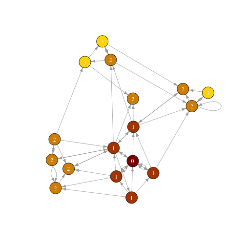

```r
dist.from.NYT <- distances(net, v=V(net)[media=="NY Times"], to=V(net), weights=NA)
# Set colors to plot the distances:
oranges <- colorRampPalette(c("dark red", "gold"))
col <- oranges(max(dist.from.NYT)+1)
col <- col[dist.from.NYT+1]

plot(net, vertex.color=col, vertex.label=dist.from.NYT, edge.arrow.size=.6,
     vertex.label.color="white")
```

### Distances and paths

We can also find the shortest path between specific nodes. Say here between MSNBC and the New York Post:

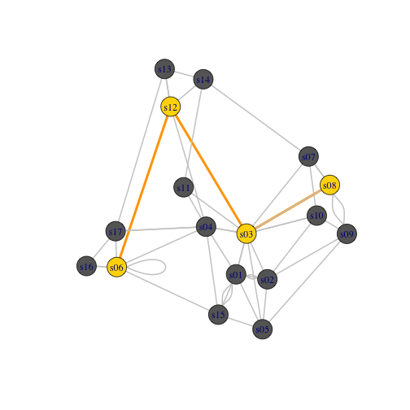

```r
news.path <- shortest_paths(net,
                            from = V(net)[media=="MSNBC"],
                             to  = V(net)[media=="New York Post"],
                             output = "both") # both path nodes and edges
# Generate edge color variable to plot the path:
ecol <- rep("gray80", ecount(net))
ecol[unlist(news.path$epath)] <- "orange"
# Generate edge width variable to plot the path:
ew <- rep(2, ecount(net))
ew[unlist(news.path$epath)] <- 4
# Generate node color variable to plot the path:
vcol <- rep("gray40", vcount(net))
vcol[unlist(news.path$vpath)] <- "gold"
plot(net, vertex.color=vcol, edge.color=ecol,
     edge.width=ew, edge.arrow.mode=0)
```

### Distances and paths

Identify the edges going into or out of a vertex, for instance the WSJ. For a single node, use 'incident()', for multiple nodes use 'incident_edges()'

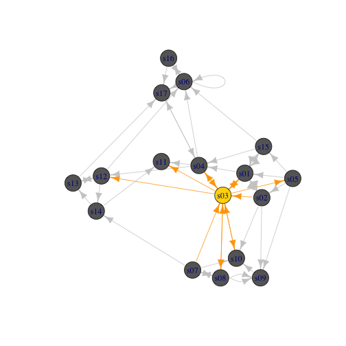

```r
inc.edges <- incident(net, V(net)[media=="Wall Street Journal"], mode="all")

# Set colors to plot the selected edges.
ecol <- rep("gray80", ecount(net))
ecol[inc.edges] <- "orange"
vcol <- rep("grey40", vcount(net))
vcol[V(net)$media=="Wall Street Journal"] <- "gold"
plot(net, vertex.color=vcol, edge.color=ecol)
```

### Distances and paths

We can also easily identify the immediate neighbors of a vertex, say WSJ. The 'neighbors' function finds all nodes one step out from the focal actor. To find the neighbors for multiple nodes, use 'adjacent_vertices()'. To find node neighborhoods going more than one step out, use function 'ego()' with parameter 'order' set to the number of steps out to go from the focal node(s).

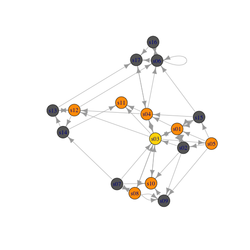

```r
neigh.nodes <- neighbors(net, V(net)[media=="Wall Street Journal"], mode="out")
# Set colors to plot the neighbors:
vcol[neigh.nodes] <- "#ff9d00"
plot(net, vertex.color=vcol)
```

### Distances and paths

```r
# For example, select edges from newspapers to online sources:
E(net)[ V(net)[type.label=="Newspaper"] %->% V(net)[type.label=="Online"] ]
```

```
+ 7/52 edges from b8afdea (vertex names):
[1] s05->s15 s06->s17 s01->s15 s06->s16 s03->s12 s04->s12 s04->s17
```

### Distances and paths

```r
# Cocitation (for a couple of nodes, how many shared nominations they have)
cocitation(net)
```

```
    s01 s02 s03 s04 s05 s06 s07 s08 s09 s10 s11 s12 s13 s14 s15 s16 s17
s01   2   1   1   3   1   2   0   1   2   2   1   1   0   0   1   0   0
s02   1   2   2   2   0   0   0   0   1   0   0   0   0   0   3   0   0
s03   1   2   0   1   0   1   1   1   3   2   1   1   0   1   1   0   1
s04   3   2   1   0   1   1   0   1   0   1   1   1   0   0   1   0   0
s05   1   0   0   1   0   0   0   1   0   1   1   1   0   0   0   0   0
s06   2   0   1   1   0   0   0   0   0   0   1   1   1   1   0   1   3
s07   0   0   1   0   0   0   0   0   2   0   0   0   0   0   0   0   0
s08   1   0   1   1   1   0   0   0   0   2   1   1   0   1   0   0   0
s09   2   1   3   0   0   0   2   0   2   1   0   0   0   0   1   0   0
s10   2   0   2   1   1   0   0   2   1   0   1   1   0   1   0   0   0
s11   1   0   1   1   1   1   0   1   0   1   0   2   1   0   0   0   1
s12   1   0   1   1   1   1   0   1   0   1   2   0   0   0   0   0   2
s13   0   0   0   0   0   1   0   0   0   0   1   0   0   1   0   0   0
s14   0   0   1   0   0   1   0   1   0   1   0   0   1   0   0   0   0
s15   1   3   1   1   0   0   0   0   1   0   0   0   0   0   0   0   0
s16   0   0   0   0   0   1   0   0   0   0   0   0   0   0   0   0   1
s17   0   0   1   0   0   3   0   0   0   0   1   2   0   0   0   1   0
```

### Subgroups and communities

Converting 'net' to an undirected network.

- There are several ways to do that: we can create an undirected link between any pair of connected nodes (mode=“collapse), or create an undirected link for each directed one (mode="each”), or create an undirected link for each symmetric link (mode=“mutual”).
- In cases when A -> B and B -> A are collapsed into a single undirected link, we need to specify what to do with the edge attributes. Here we have said that the 'weight' of links should be summed, and all other edge attributes ignored.

```r
net.sym <- as.undirected(net, mode="collapse", edge.attr.comb=list(weight="sum", "ignore"))
```

### Subgroups and communities

```r
# Find cliques (complete subgraphs of an undirected graph)
cliques(net.sym) # list of cliques
```

```
[[1]]
+ 1/17 vertex, named, from 8bbaec7:
[1] s03

[[2]]
+ 1/17 vertex, named, from 8bbaec7:
[1] s06

[[3]]
+ 1/17 vertex, named, from 8bbaec7:
[1] s14

[[4]]
+ 1/17 vertex, named, from 8bbaec7:
[1] s09

[[5]]
+ 1/17 vertex, named, from 8bbaec7:
[1] s04

[[6]]
+ 2/17 vertices, named, from 8bbaec7:
[1] s04 s06

[[7]]
+ 2/17 vertices, named, from 8bbaec7:
[1] s03 s04

[[8]]
+ 1/17 vertex, named, from 8bbaec7:
[1] s05

[[9]]
+ 2/17 vertices, named, from 8bbaec7:
[1] s05 s09

[[10]]
+ 2/17 vertices, named, from 8bbaec7:
[1] s03 s05

```

[output cut: 244 more lines]

```
[[72]]
+ 3/17 vertices, named, from 8bbaec7:
[1] s02 s05 s09

[[73]]
+ 3/17 vertices, named, from 8bbaec7:
[1] s02 s03 s05

[[74]]
+ 2/17 vertices, named, from 8bbaec7:
[1] s02 s09

[[75]]
+ 2/17 vertices, named, from 8bbaec7:
[1] s02 s03
```

### Subgroups and communities

```r
# Find cliques (complete subgraphs of an undirected graph)
sapply(cliques(net.sym), length) # clique sizes
```

```
 [1] 1 1 1 1 1 2 2 1 2 2 1 2 1 2 2 1 2 1 2 2 1 2 3 2 3 2 1 2 3 2 2 3 2 1 2
[36] 3 2 3 3 2 2 2 1 2 3 2 2 1 2 3 2 3 2 2 1 2 3 3 2 2 3 2 1 2 3 4 3 2 3 3
[71] 2 3 3 2 2
```

### Subgroups and communities

```r
# Find cliques (complete subgraphs of an undirected graph)
largest_cliques(net.sym) # cliques with max number of nodes
```

```
[[1]]
+ 4/17 vertices, named, from 8bbaec7:
[1] s03 s01 s02 s05
```

### Subgroups and communities

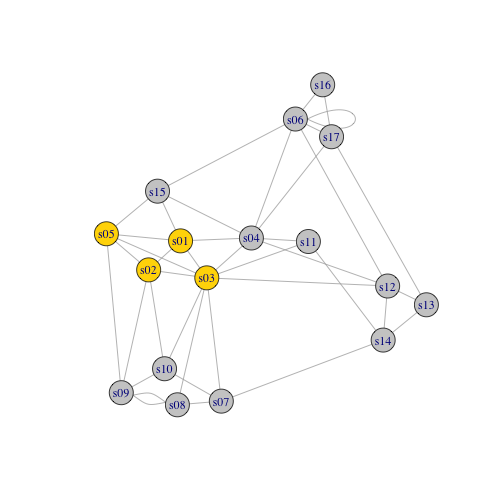

```r
vcol <- rep("grey80", vcount(net.sym))
vcol[unlist(largest_cliques(net.sym))] <- "gold"
plot(net.sym, vertex.label=V(net.sym)$name, vertex.color=vcol)
```

### Communities

- A number of algorithms aim to detect groups that consist of densely connected nodes with fewer connections across groups.
- Community detection based on edge betweenness (Newman-Girvan)
  - High-betweenness edges are removed sequentially (recalculating at each step) and the best partitioning of the network is selected.

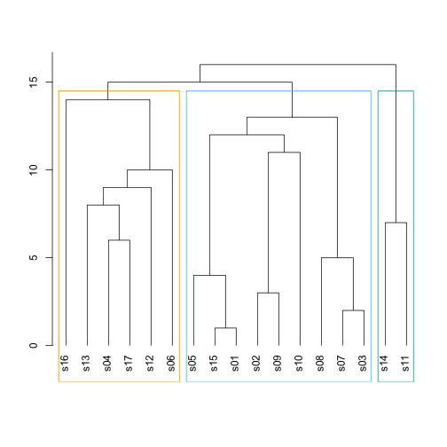

```r
ceb <- cluster_edge_betweenness(net)
dendPlot(ceb, mode="hclust")
```

### Communities

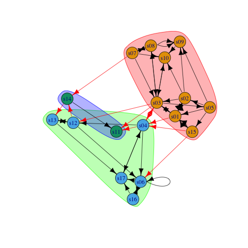

```r
plot(ceb, net)
```

### Communities

```r
# Let's examine the community detection igraph object:
class(ceb)
```

```
[1] "communities"
```

```r
length(ceb)     # number of communities
```

```
[1] 3
```

```r
membership(ceb) # community membership for each node
```

```
s01 s02 s03 s04 s05 s06 s07 s08 s09 s10 s11 s12 s13 s14 s15 s16 s17
  1   1   1   2   1   2   1   1   1   1   3   2   2   3   1   2   2
```

### Communities

```r
crossing(ceb, net)   # boolean vector: TRUE for edges across communities
```

```
s01|s02 s01|s02 s01|s03 s01|s04 s04|s11 s05|s15 s06|s17 s08|s09 s08|s09
  FALSE   FALSE   FALSE    TRUE    TRUE   FALSE   FALSE   FALSE   FALSE
s03|s04 s04|s03 s01|s15 s15|s01 s15|s01 s16|s17 s16|s06 s06|s16 s09|s10
   TRUE    TRUE   FALSE   FALSE   FALSE   FALSE   FALSE   FALSE   FALSE
s08|s07 s07|s08 s07|s10 s05|s02 s02|s03 s02|s01 s03|s01 s12|s13 s12|s14
  FALSE   FALSE   FALSE   FALSE   FALSE   FALSE   FALSE   FALSE    TRUE
s14|s13 s13|s12 s05|s09 s02|s10 s03|s12 s04|s06 s10|s03 s03|s10 s04|s12
   TRUE   FALSE   FALSE   FALSE    TRUE   FALSE   FALSE   FALSE   FALSE
s13|s17 s06|s06 s14|s11 s03|s11 s12|s06 s04|s17 s17|s04 s08|s03 s03|s08
  FALSE   FALSE   FALSE    TRUE   FALSE   FALSE   FALSE   FALSE   FALSE
s07|s14 s15|s06 s15|s04 s05|s01 s02|s09 s03|s05 s07|s03
   TRUE    TRUE    TRUE   FALSE   FALSE   FALSE   FALSE
```

### Communities

```r
modularity(ceb) # how modular the graph partitioning is
```

```
[1] 0.2903704
```

High modularity for a partitioning reflects dense connections WITHIN communities and sparse connections ACROSS communities.

### Communities

- Community detection based on propagating labels
- Assigns node labels, randomizes, and replaces each vertex's label with the label that appears most frequently among neighbors. Repeated until each vertex has the most common label of its neighbors.

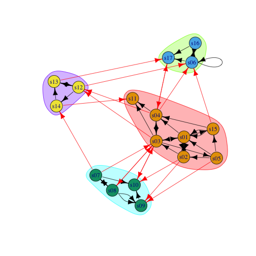

```r
clp <- cluster_label_prop(net)
plot(clp, net)
```

### Communities

- Community detection based on greedy optimization of modularity

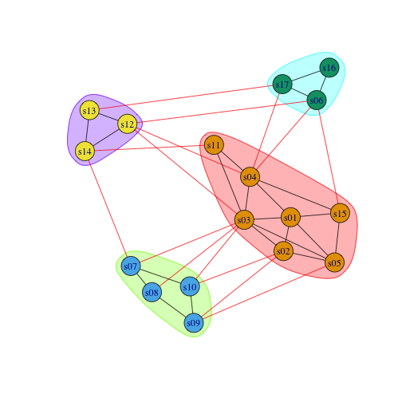

```r
net = simplify(net) #no multiple edges
cfg <- cluster_fast_greedy(as.undirected(net))
plot(cfg, as.undirected(net))
```

### Communities

We can also plot the communities without relying on their built-in plot:

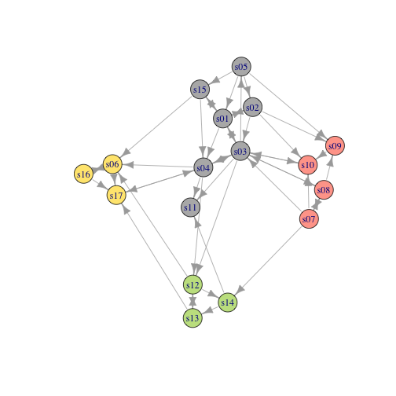

```r
V(net)$community <- cfg$membership
colrs <- adjustcolor( c("gray50", "tomato", "gold", "yellowgreen"), alpha=.6)
plot(net, vertex.color=colrs[V(net)$community])
```

### Communities

K-core decomposition

- The k-core is the maximal subgraph in which every node has degree of at least k
  - This also means that the (k+1)-core will be a subgraph of the k-core.
  - The result here gives the coreness of each vertex in the network.

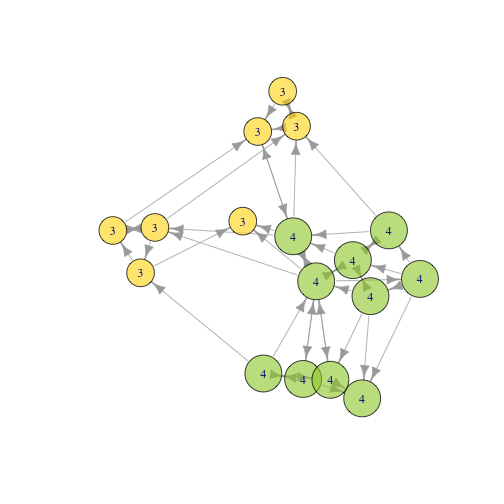

```r
kc <- coreness(net, mode="all")
plot(net, vertex.size=kc*6, vertex.label=kc, vertex.color=colrs[kc])
```

### Assortativity and Homophily

Assortativity (homophily)

- The tendency of nodes to connect to others who are similar on some variable.
  - assortativity_nominal() is for categorical variables (labels)
  - assortativity() is for ordinal and above variables
  - assortativity_degree() checks assortativity in node degrees

```r
V(net)$type.label
```

```
 [1] "Newspaper" "Newspaper" "Newspaper" "Newspaper" "Newspaper"
 [6] "Newspaper" "TV"        "TV"        "TV"        "TV"
[11] "TV"        "Online"    "Online"    "Online"    "Online"
[16] "Online"    "Online"
```

```r
V(net)$media.type
```

```
 [1] 1 1 1 1 1 1 2 2 2 2 2 3 3 3 3 3 3
```

### Assortativity and Homophily

```r
assortativity_nominal(net, V(net)$media.type, directed=F)
```

```
[1] 0.1715568
```

```r
assortativity(net, V(net)$audience.size, directed=F)
```

```
[1] -0.1102857
```

```r
assortativity_degree(net, directed=F)
```

```
[1] -0.009551146
```